# Practical 2

## Question 15:

**Give the line a nice colour and increase its size. Also add points of the same colour on top.**

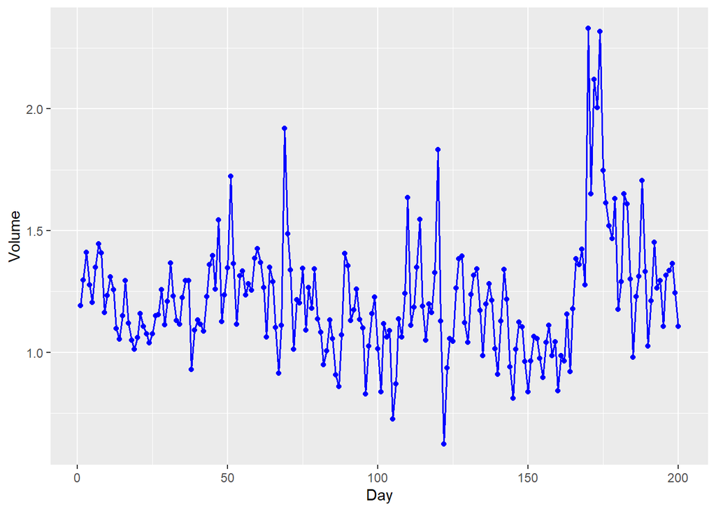

```r
Smarket[1:200,] %>%
  mutate(Day = 1:200 ) %>%
  ggplot(mapping = aes(x = Day, y = Volume)) +
  geom_line(colour = "blue", size = 0.6) +
  geom_point(colour = "blue")
```

## Question 16:

**Use the function which.max() to find out which of the first 200 days has the highest trade volume and use the function max() to find out how large this volume was.**

```r
day_max = which.max(Smarket[1:200,]$Volume)
```

```r
vol_max = max(Smarket[1:200,]$Volume)
```

## Question 17:

**Use geom_label(aes(x = your_x, y = your_y, label = “Peak volume”)) to add a label to this day. You can use either the values or call the functions. Place the label near the peak!**

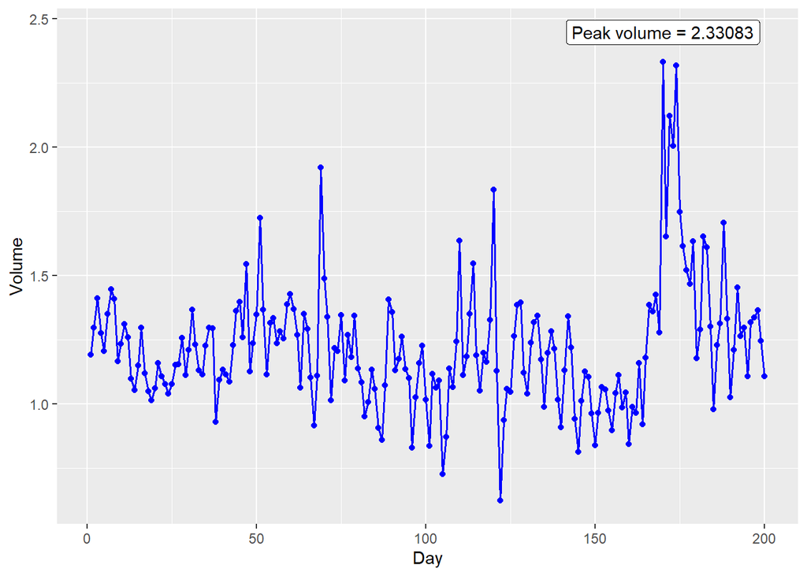

```r
Smarket[1:200,] %>%
  mutate(Day = 1:200 ) %>%
  ggplot(mapping = aes(x = Day, y = Volume)) +
  geom_line(colour = "blue", size = 0.6) +
  geom_point(colour = "blue") +
  geom_label(aes(x = day_max, y = 1.05*vol_max, label = paste("Peak volume =", as.character(vol_max))))
```

## Question 18:

**Create a data frame called baseball based on the Hitters dataset. In this data frame, create a factor variable which splits players’ salary range into 3 categories. Tip: use the filter() function to remove the missing values, and then use the cut() function and assign nice labels to the categories. In addition, create a variable which indicates the proportion of career hits that was a home run.**

```r
baseball <- Hitters %>%
  filter(!is.na(Salary)) %>%
  mutate(
    salary_range = cut(Salary, breaks = 3, labels = c("Low", "Medium", "High")),
    homeruns_to_hits = CHmRun / CHits
  )
```

## Question 19:

**Create a scatter plot where you map CWalks to the x position and the proportion you calculated in the previous exercise to the y position. Fix the y axis limits to (0, 0.4) and the x axis to (0, 1600) using ylim() and xlim(). Add nice x and y axis titles using the labs() function. Save the plot as the variable baseball_plot.**

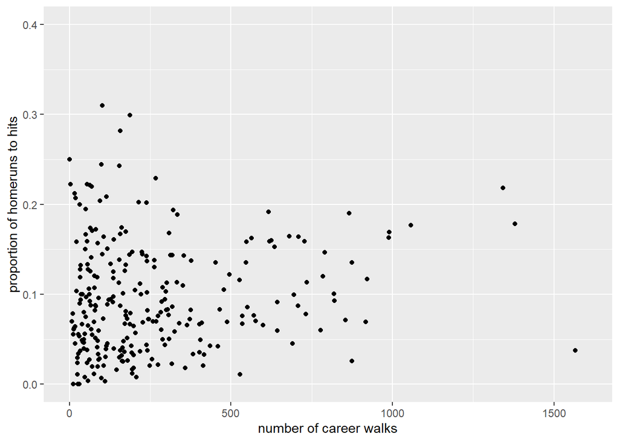

```r
baseball_plot <- ggplot(data = baseball, mapping = aes(x = CWalks, y = homeruns_to_hits)) +
  geom_point() +
  xlim(0, 1600) +
  ylim(0, 0.4) +
  labs(x = "number of career walks", y = "proportion of homeruns to hits")
baseball_plot
```

## Question 20:

**Split up this plot into three parts based on the salary range variable you calculated. Use the facet_wrap() function for this; look at the examples in the help file for tips.**

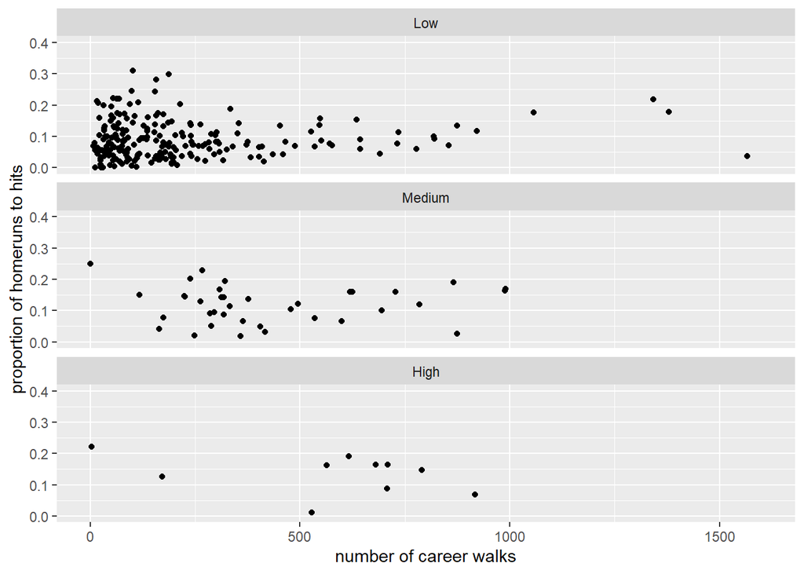

```r
baseball_plot +
  facet_wrap(vars(salary_range), nrow = 3)
```

## Final exercise:

**Create an interesting data visualisation based on the Carseats data from the ISLR package.**

```r
head(Carseats)
```

```
##   Sales CompPrice Income Advertising Population Price ShelveLoc Age Education
## 1  9.50       138     73          11        276   120       Bad  42        17
## 2 11.22       111     48          16        260    83      Good  65        10
## 3 10.06       113     35          10        269    80    Medium  59        12
## 4  7.40       117    100           4        466    97    Medium  55        14
## 5  4.15       141     64           3        340   128       Bad  38        13
## 6 10.81       124    113          13        501    72       Bad  78        16
##   Urban  US
## 1   Yes Yes
## 2   Yes Yes
## 3   Yes Yes
## 4   Yes Yes
## 5   Yes  No
## 6    No Yes
```

We would expect “Advertising” to be an important variable for predicting sales at a given location. Let us have a closer look at it:

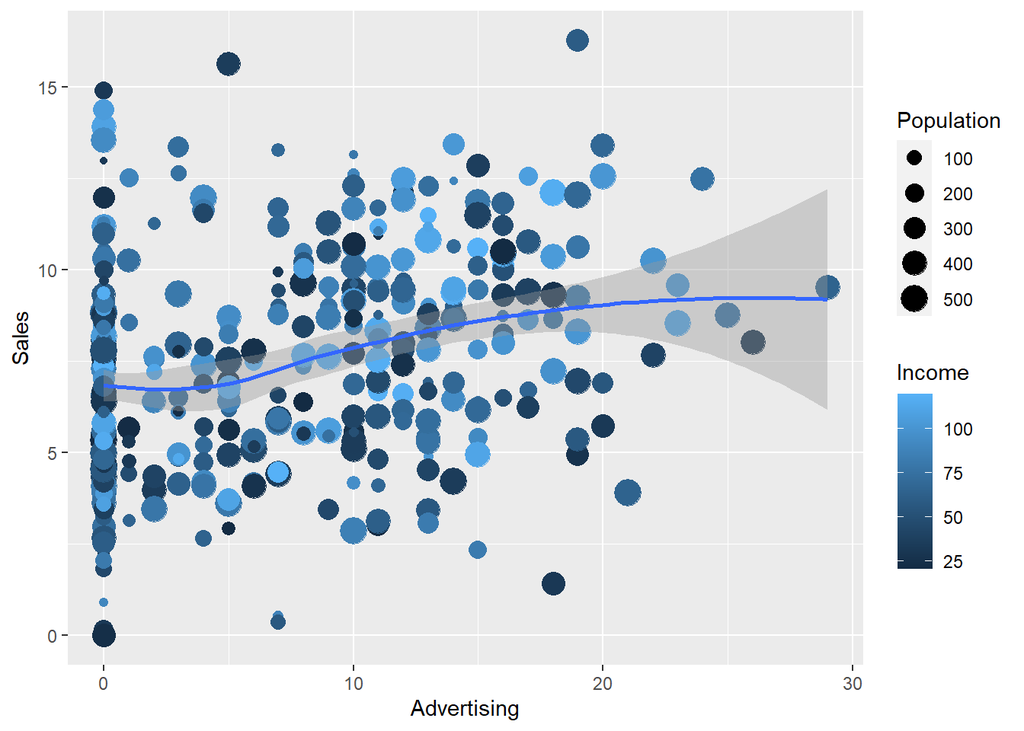

```r
adv_plot <- ggplot(data = Carseats, mapping = aes(x = Advertising, y = Sales)) +
  geom_point(mapping = aes(color = Income, size = Population )) +
  geom_smooth()
adv_plot
```

There seems to be quite little influence, but it might be more meaningful to plot “Advertising_per_person” vs “Sales_per_person” for a given location. This shows how heavy is the presence of advertising in a given location, and what is the fraction of people actually affected by it.

Make a new dataset which has these quantities calculated per capita, as well as two different categories for age, since we expect young families to buy more car seats.

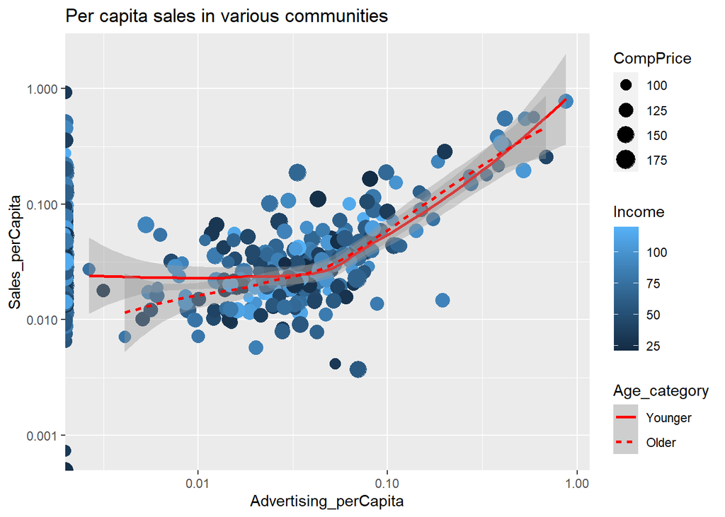

```r
CarseatsIntr <- Carseats %>%
  mutate(Sales_perCapita = Sales / Population,
         Advertising_perCapita = Advertising / Population,
         Age_category = cut(Age, breaks = 2, labels = c("Younger", "Older") ),
         Advertising_category = cut(Advertising_perCapita, breaks = c(0, 0.0001, 0.1,Inf), labels =c("No advertising", "Below 0.1 $ p.c.", "Above 0.1 $ p.c."))
  )


# now let us plot the same for "intrinsic" rather than exrtrinsic variables:
advIntr_plot <- ggplot(data = CarseatsIntr, mapping = aes(x = Advertising_perCapita, y = Sales_perCapita)) +
  geom_point(mapping = aes(colour = Income, size = CompPrice)) +
  geom_smooth(mapping = aes(linetype = Age_category), colour = "red") +
  scale_x_continuous(trans='log10') +
  scale_y_continuous(trans='log10') +
  labs(title = "Per capita sales in various communities" )
advIntr_plot
```

Until the per capita advertising expenditure reaches roughly 0.03, young people clearly spend more on child seats than old people. Interestingly, it seems that **big enough advertising can convince old people that they need child seats**. (not really, but it sounds like a catchy headline…) Also, there is no clear trend for richer locations to be better advertising investments than poorer locations.

What is also interesting is that while really large per capita advertising produces larger per capita sales, the overall vertical range does not differ from the places with no advertising at all (collapsed onto y axis).

```r
2+2
```

```
## [1] 4
```